# Tissue-specific multivariable Mendelian randomization analysis on the risk of Alzheimer’s disease

Ryan Liu, Chong Jin

10/08/2022

# Framework

In this project, we strive to identify how the gene expression in blood and brain mediate the causal effects of intelligence and educational attainment on the risk of Alzheimer’s disease.

The idea of elucidating the causal pathways mediated by multiple tissues is from:

Leyden, Genevieve M., et al. “Harnessing tissue-specific genetic variation to dissect putative causal pathways between body mass index and cardiometabolic phenotypes.” The American Journal of Human Genetics 109.2 (2022): 240-252.

The idea of finding out independent effects of educational attainment and intelligence on the risk of Alzheimer’s disease comes from:

Anderson, Emma L., et al. “Education, intelligence and Alzheimer’s disease: evidence from a multivariable two-sample Mendelian randomization study.” International journal of epidemiology 49.4 (2020): 1163-1172.

Datasets:

1. Savage et al.: The intelligence GWAS dataset. The study was published as:

Savage, Jeanne E., et al. 2018. “Genome-Wide Association Meta-Analysis in 269,867 Individuals Identifies New Genetic and Functional Links to Intelligence.” Nature Genetics 50 (7): 912–19.

2. Hill et al.: The intelligence GWAS dataset through multi-trait analysis using an earlier study by Okbay et al. Only data after LD clumping are available. The study was published as:

Hill, W. D., R. E. Marioni, O. Maghzian, S. J. Ritchie, S. P. Hagenaars, A. M. McIntosh, C. R. Gale, G. Davies, and I. J. Deary. 2019. “A Combined Analysis of Genetically Correlated Traits Identifies 187 Loci and a Role for Neurogenesis and Myelination in Intelligence.” Molecular Psychiatry 24 (2): 169–81.

3. Okbay et al.: The educational attainment GWAS dataset. The full GWAS summary statistics does not include the 23andme samples, while the statistics after LD clumping has them. The latter one is used when selecting the instrumental variables while the former one is used during colocalization analysis. The study was published as:

Okbay, Aysu, et al. “Polygenic prediction of educational attainment within and between families from genome-wide association analyses in 3 million individuals.” Nature genetics 54.4 (2022): 437-449.

4. IGAP late stage Alzheimer’s disease dataset: from the IEU OpenGWAS dataset https://gwas.mrcieu.ac.uk/.
5. eQTL of brain: BrainMeta_cis_eqtl_summary.tar.gz (hg19) (2.6 GB) from https://yanglab.westlake.edu.cn/software/smr/#eQTLsummarydata.
6. eQTL of blood: cage_eqtl_data_hg19.tgz (hg19) (3.8 GB) from https://yanglab.westlake.edu.cn/software/smr/#eQTLsummarydata.

The colocalization analysis:

1. IV selection: from Savage et al.; then use Savage et al. GWAS summary statistics to perform colocalization with eQTL summary statistics of blood and brain.
2. IV selection: from Hill et al.; then use Savage et al. GWAS summary statistics to perform colocalization with eQTL summary statistics of blood and brain.
3. IV selection: from Okbay et al.; then use Okbay et al. GWAS summary statistics to perform colocalization with eQTL summary statistics of blood and brain.

Below, we illustrate the instrumental variables that we are using:

## Savage et al. (Nature Genetics 2018) Intelligence

```r
library(tidyverse)
```

```r
library(qqman)
library(TwoSampleMR)
add_CI = function(x) {
  x$CI_lower = x$b - 1.96 * x$se
  x$CI_upper = x$b + 1.96 * x$se
  x
}
```

```r
IV_file = "analysis_IV_Savage_coloc_Savage_BrainMeta_cis_eqtl_summary/IV_dataset.csv"
if (file.exists(IV_file)) {
  IVs = read_csv(IV_file)
  print(max(IVs$pval.exposure))
  manhattan(IVs, chr="chr.exposure", bp="pos.exposure", snp="SNP", p="pval.exposure", main = "IVs from Savage GWAS")
}
```

```
## [1] 9.96896e-06
```

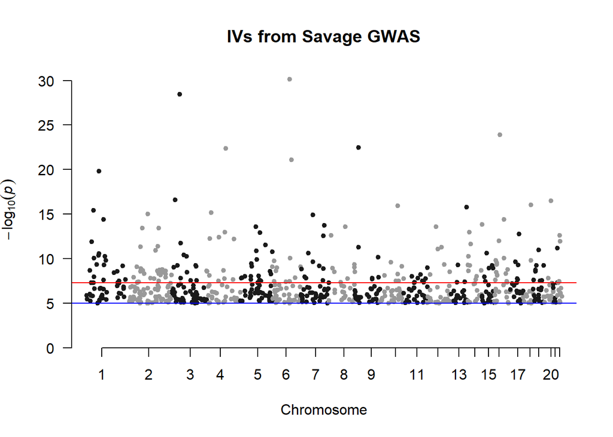

## Hill et al. (Molecular Psychiatry 2019) Intelligence with multi-trait analysis

```r
IV_file = "analysis_IV_Hill_coloc_Savage_BrainMeta_cis_eqtl_summary/IV_dataset.csv"
if (file.exists(IV_file)) {
  IVs = read_csv(IV_file)
  print(max(IVs$pval.exposure))
  manhattan(IVs, chr="chr.exposure", bp="pos.exposure", snp="SNP", p="pval.exposure", main = "IVs from Hill GWAS")
}
```

```
## [1] 4.973287e-08
```

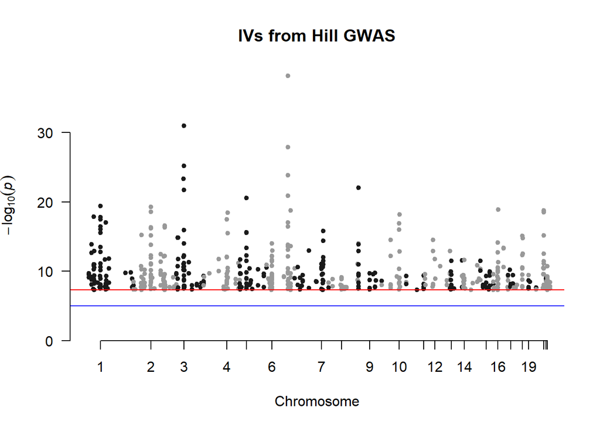

## Okbay et al. (Nature Genetics 2022) Educational attainment

```r
IV_file = "analysis_IV_Okbay_coloc_Okbay_BrainMeta_cis_eqtl_summary/IV_dataset.csv"
if (file.exists(IV_file)) {
  IVs = read_csv(IV_file)
  print(max(IVs$pval.exposure))
  manhattan(IVs, chr="chr.exposure", bp="pos.exposure", snp="SNP", p="pval.exposure", main = "IVs from Okbay GWAS")
}
```

```
## [1] 9.965e-06
```

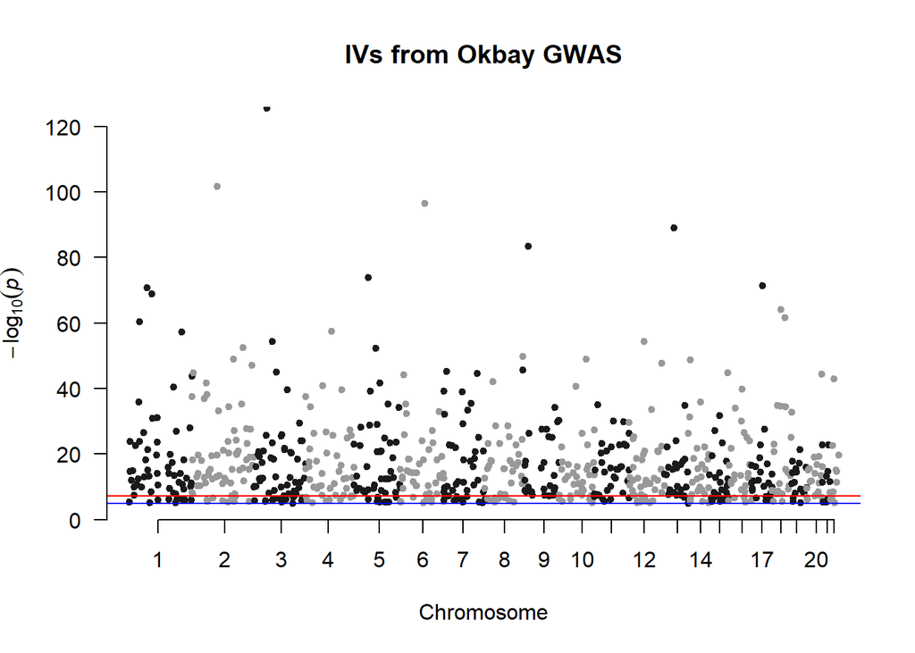

# Mendelian randomization analysis

## Savage et al. (Nature Genetics 2018) Intelligence and Okbay et al. (Nature Genetics 2022) Educational attainment

This analysis is described in `` run_coloc_all.R``. From Okbay et al. we take the summary statistics of the preclumped data with p-value cutoff 1e-5. From Savage et al., we obtain data by ``extract_instruments(“ebi-a-GCST006250”, r2=0.01, kb=10000, p1=1e-5)`. Next, we combine the GWAS summary statistics from the two studies the same time and perform LD clumping using the cutoff of r2=0.001. We can partition the list of combined SNPs by whether they are from Savage et al. (715 SNPs) or from Okbay et al (755 SNPs). For each of the list of SNPs from the educational attainment studies and the educational attainment studies, we use`coloc.abp()` to obtain SNPs colocalizing with blood tissue expression and brain tissue expression.

### Multivariable MR

`analysis_IV_OkbaySavage_coloc_Okbay_BrainMeta_cis_eqtl_summary/`

`analysis_IV_OkbaySavage_coloc_Okbay_cage_eqtl_data/`

`analysis_IV_OkbaySavage_coloc_Savage_BrainMeta_cis_eqtl_summary/`

`analysis_IV_OkbaySavage_coloc_Savage_cage_eqtl_data/`

```r
#MVMR
exposure_edu_data <- read_csv('analysis_IV_OkbaySavage_coloc_Okbay_cage_eqtl_data/IV_dataset.csv')
exposure_IQ_data <- read_csv('analysis_IV_OkbaySavage_coloc_Savage_cage_eqtl_data/IV_dataset.csv')
exposure_shared_SNPs <- intersect(exposure_edu_data$SNP, exposure_IQ_data$SNP)
exposure_edu_data <- exposure_edu_data[match(exposure_shared_SNPs, exposure_edu_data$SNP), ]
exposure_IQ_data <- exposure_edu_data[match(exposure_shared_SNPs, exposure_IQ_data$SNP), ]

coloc_brain_edu <- read.csv('analysis_IV_OkbaySavage_coloc_Okbay_BrainMeta_cis_eqtl_summary/coloc_vector_expression_combined.csv')
coloc_cage_edu <- read.csv('analysis_IV_OkbaySavage_coloc_Okbay_cage_eqtl_data/coloc_vector_expression_combined.csv')
coloc_brain_IQ <- read.csv('analysis_IV_OkbaySavage_coloc_Savage_BrainMeta_cis_eqtl_summary/coloc_vector_expression_combined.csv')
coloc_cage_IQ <- read.csv('analysis_IV_OkbaySavage_coloc_Savage_cage_eqtl_data/coloc_vector_expression_combined.csv')
coloc_brain_edu <- dplyr::filter(coloc_brain_edu,is_coloc)
coloc_cage_edu <- dplyr::filter(coloc_cage_edu,is_coloc)
coloc_brain_IQ <- dplyr::filter(coloc_brain_IQ,is_coloc)
coloc_cage_IQ <- dplyr::filter(coloc_cage_IQ,is_coloc)
coloc_brain_edu_snps <- coloc_brain_edu[,1]
coloc_cage_edu_snps <- coloc_cage_edu[,1]
coloc_brain_IQ_snps <- coloc_brain_IQ[,1]
coloc_cage_IQ_snps <- coloc_cage_IQ[,1]
coloc_brain_edu_snps <- intersect(exposure_shared_SNPs, coloc_brain_edu_snps)
coloc_cage_edu_snps <- intersect(exposure_shared_SNPs, coloc_cage_edu_snps)
coloc_brain_IQ_snps <- intersect(exposure_shared_SNPs, coloc_brain_IQ_snps)
coloc_cage_IQ_snps <- intersect(exposure_shared_SNPs, coloc_cage_IQ_snps)

exposure_edu_data_brain <- dplyr::filter(exposure_edu_data,SNP %in% coloc_brain_edu_snps | SNP %in% coloc_cage_edu_snps)
exposure_edu_data_brain[(exposure_edu_data_brain$SNP %in% coloc_cage_edu_snps) & !(exposure_edu_data_brain$SNP %in% coloc_brain_edu_snps), 'beta.exposure'] <- 0
exposure_edu_data_brain[(exposure_edu_data_brain$SNP %in% coloc_cage_edu_snps) & !(exposure_edu_data_brain$SNP %in% coloc_brain_edu_snps), 'se.exposure'] <- 0
exposure_edu_data_brain[(exposure_edu_data_brain$SNP %in% coloc_cage_edu_snps) & !(exposure_edu_data_brain$SNP %in% coloc_brain_edu_snps), 'pval.exposure'] <- 0
exposure_edu_data_cage <- dplyr::filter(exposure_edu_data,SNP %in% coloc_brain_edu_snps | SNP %in% coloc_cage_edu_snps)
exposure_edu_data_cage[(exposure_edu_data_brain$SNP %in% coloc_brain_edu_snps) & !(exposure_edu_data_brain$SNP %in% coloc_cage_edu_snps), 'beta.exposure'] <- 0
exposure_edu_data_cage[(exposure_edu_data_brain$SNP %in% coloc_brain_edu_snps) & !(exposure_edu_data_brain$SNP %in% coloc_cage_edu_snps), 'se.exposure'] <- 0
exposure_edu_data_cage[(exposure_edu_data_brain$SNP %in% coloc_brain_edu_snps) & !(exposure_edu_data_brain$SNP %in% coloc_cage_edu_snps), 'pval.exposure'] <- 0
exposure_IQ_data_brain <- dplyr::filter(exposure_IQ_data,SNP %in% coloc_brain_IQ_snps | SNP %in% coloc_cage_IQ_snps)
exposure_IQ_data_brain[(exposure_IQ_data_brain$SNP %in% coloc_cage_IQ_snps) & !(exposure_IQ_data_brain$SNP %in% coloc_brain_IQ_snps), 'beta.exposure'] <- 0
exposure_IQ_data_brain[(exposure_IQ_data_brain$SNP %in% coloc_cage_IQ_snps) & !(exposure_IQ_data_brain$SNP %in% coloc_brain_IQ_snps), 'se.exposure'] <- 0
exposure_IQ_data_brain[(exposure_IQ_data_brain$SNP %in% coloc_cage_IQ_snps) & !(exposure_IQ_data_brain$SNP %in% coloc_brain_IQ_snps), 'pval.exposure'] <- 0
exposure_IQ_data_cage <- dplyr::filter(exposure_IQ_data,SNP %in% coloc_brain_IQ_snps | SNP %in% coloc_cage_IQ_snps)
exposure_IQ_data_cage[(exposure_IQ_data_brain$SNP %in% coloc_brain_IQ_snps) & !(exposure_IQ_data_brain$SNP %in% coloc_cage_IQ_snps), 'beta.exposure'] <- 0
exposure_IQ_data_cage[(exposure_IQ_data_brain$SNP %in% coloc_brain_IQ_snps) & !(exposure_IQ_data_brain$SNP %in% coloc_cage_IQ_snps), 'se.exposure'] <- 0
exposure_IQ_data_cage[(exposure_IQ_data_brain$SNP %in% coloc_brain_IQ_snps) & !(exposure_IQ_data_brain$SNP %in% coloc_cage_IQ_snps), 'pval.exposure'] <- 0
exposure_edu_data_brain['id.exposure']<-'Savage.2018.brain'
exposure_edu_data_brain['exposure']<-'Savage.2018.brain'
exposure_edu_data_cage['id.exposure']<-'Savage.2018.cage'
exposure_edu_data_cage['exposure']<-'Savage.2018.cage'
exposure_IQ_data_brain['id.exposure']<-'Okbay.2022.brain'
exposure_IQ_data_brain['exposure']<-'Okbay.2022.brain'
exposure_IQ_data_cage['id.exposure']<-'Okbay.2022.cage'
exposure_IQ_data_cage['exposure']<-'Okbay.2022.cage'
exposure_data_all <- do.call("rbind", list(exposure_edu_data_brain,exposure_edu_data_cage,exposure_IQ_data_brain,exposure_IQ_data_cage))
outcome_data_mv <- extract_outcome_data(snps=exposure_data_all$SNP, outcomes = "ebi-a-GCST002245")
```

```
## API: public: http://gwas-api.mrcieu.ac.uk/
## Extracting data for 183 SNP(s) from 1 GWAS(s)
## Finding proxies for 11 SNPs in outcome ebi-a-GCST002245
## Extracting data for 11 SNP(s) from 1 GWAS(s)
```

```r
mvdat <- mv_harmonise_data(exposure_data_all,outcome_data_mv)
```

```
## Harmonising Savage.2018.brain (Savage.2018.brain) and Alzheimer's disease (late onset) || id:ebi-a-GCST002245 (ebi-a-GCST002245)
## Removing the following SNPs for being palindromic with intermediate allele frequencies:
## rs10929474, rs14184, rs1689510, rs72801843, rs9496630
```

```r
# Harmonising Savage.2018.brain (Savage.2018.brain) and Alzheimer's disease (late onset) || id:ebi-a-GCST002245 (ebi-a-GCST002245)
# Removing the following SNPs for being palindromic with intermediate allele frequencies:
# rs10929474, rs14184, rs1689510, rs28451864, rs7040995, rs72801843, rs9496630
res_main_analysis <- mv_multiple(mvdat)$result
add_CI(res_main_analysis)
```

```
##         id.exposure          exposure       id.outcome
## 1  Okbay.2022.brain  Okbay.2022.brain ebi-a-GCST002245
## 2   Okbay.2022.cage   Okbay.2022.cage ebi-a-GCST002245
## 3 Savage.2018.brain Savage.2018.brain ebi-a-GCST002245
## 4  Savage.2018.cage  Savage.2018.cage ebi-a-GCST002245
##                                                   outcome nsnp          b
## 1 Alzheimer's disease (late onset) || id:ebi-a-GCST002245   22  0.9560937
## 2 Alzheimer's disease (late onset) || id:ebi-a-GCST002245   34  0.3120390
## 3 Alzheimer's disease (late onset) || id:ebi-a-GCST002245   23 -1.5876135
## 4 Alzheimer's disease (late onset) || id:ebi-a-GCST002245   29 -0.4482840
##          se        pval   CI_lower   CI_upper
## 1 0.5991739 0.110558832 -0.2182872  2.1304746
## 2 0.5054379 0.536994853 -0.6786192  1.3026972
## 3 0.5840847 0.006565359 -2.7324195 -0.4428076
## 4 0.4874350 0.357740183 -1.4036565  0.5070885
```

```r
library(hudson)  # devtools::install_github('anastasia-lucas/hudson')
library(grid)
library(VennDiagram)
```

```
## [1] "Saving plot to phemirror.png"
```

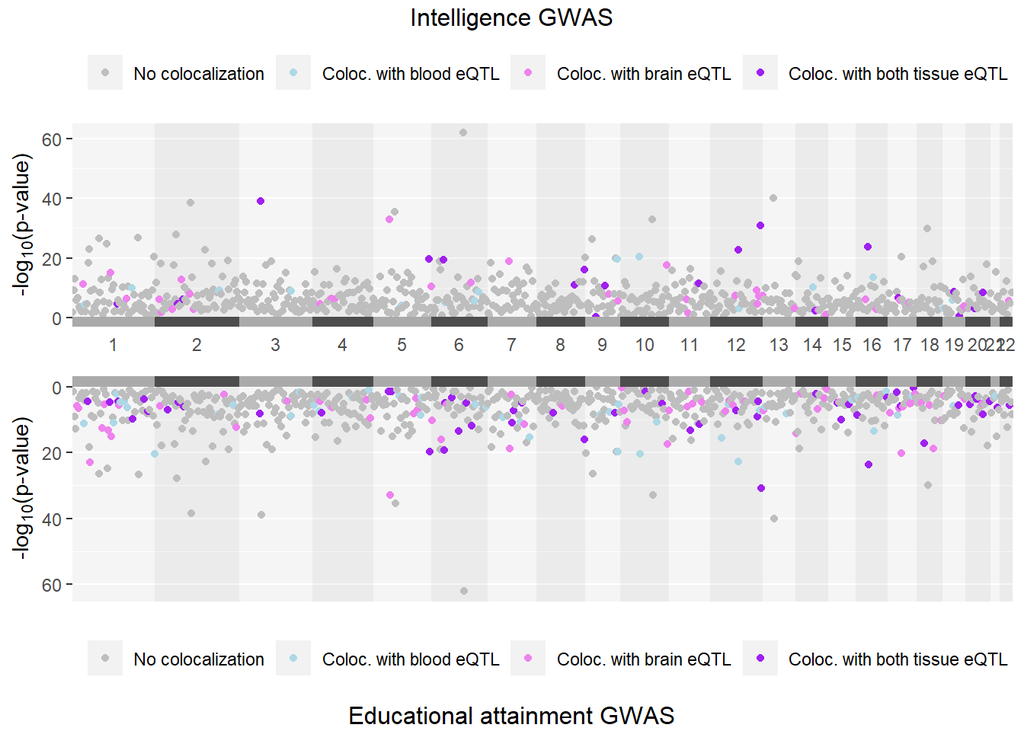

```r
exposure_IQ_data_for_hudson = exposure_IQ_data %>% rename(POS = pos.exposure, CHR = chr.exposure, pvalue = pval.exposure)
exposure_IQ_data_for_hudson$PHE = "No colocalization"
exposure_IQ_data_for_hudson$PHE[match(setdiff(coloc_brain_IQ_snps, coloc_cage_IQ_snps), exposure_IQ_data_for_hudson$SNP)] = "Coloc. with brain eQTL"
exposure_IQ_data_for_hudson$PHE[match(setdiff(coloc_cage_IQ_snps, coloc_brain_IQ_snps), exposure_IQ_data_for_hudson$SNP)] = "Coloc. with blood eQTL"
exposure_IQ_data_for_hudson$PHE[match(intersect(coloc_cage_IQ_snps, coloc_brain_IQ_snps), exposure_IQ_data_for_hudson$SNP)] = "Coloc. with both tissue eQTL"
exposure_IQ_data_for_hudson$PHE = factor(exposure_IQ_data_for_hudson$PHE, levels = c("No colocalization",
                                                                                     "Coloc. with blood eQTL",
                                                                                     "Coloc. with brain eQTL",
                                                                                     "Coloc. with both tissue eQTL"))
exposure_edu_data_for_hudson = exposure_edu_data %>% rename(POS = pos.exposure, CHR = chr.exposure, pvalue = pval.exposure)
exposure_edu_data_for_hudson$PHE = "No colocalization"
exposure_edu_data_for_hudson$PHE[match(setdiff(coloc_brain_edu_snps, coloc_cage_edu_snps), exposure_edu_data_for_hudson$SNP)] = "Coloc. with brain eQTL"
exposure_edu_data_for_hudson$PHE[match(setdiff(coloc_cage_edu_snps, coloc_brain_edu_snps), exposure_edu_data_for_hudson$SNP)] = "Coloc. with blood eQTL"
exposure_edu_data_for_hudson$PHE[match(intersect(coloc_cage_edu_snps, coloc_brain_edu_snps), exposure_edu_data_for_hudson$SNP)] = "Coloc. with both tissue eQTL"
exposure_edu_data_for_hudson$PHE = factor(exposure_edu_data_for_hudson$PHE, levels = c("No colocalization",
                                                                                     "Coloc. with blood eQTL",
                                                                                     "Coloc. with brain eQTL",
                                                                                     "Coloc. with both tissue eQTL"))
# mirrored manhattan plot
phemirror(top=exposure_IQ_data_for_hudson, bottom = exposure_edu_data_for_hudson,
          toptitle = "Intelligence GWAS", bottomtitle = "Educational attainment GWAS",
          groupcolors = rgb(t(col2rgb(c("grey", "lightblue", "violet", "purple"))), alpha = 0.5, maxColorValue = 255), wi = 13)
```

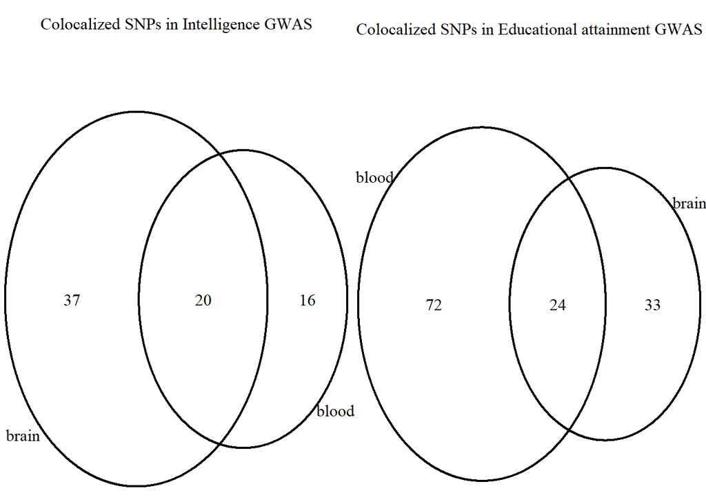

```r
# Venn diagram
library(gridExtra)
library(cowplot)
p1 = venn.diagram(list(blood=coloc_cage_IQ_snps, brain=coloc_brain_IQ_snps), filename = NULL, sub = "Colocalized SNPs in Intelligence GWAS")
# Venn diagram
p2 = venn.diagram(list(blood=coloc_cage_edu_snps, brain=coloc_brain_IQ_snps), filename = NULL, sub = "Colocalized SNPs in Educational attainment GWAS")
plot_grid(p1, p2, align = "h", ncol = 2, rel_widths = c(1/2, 1/2))
```

**SNPs showing evidence of genetic colocalization between variants selected as instrumental variables and gene expression derived from brain, blood, or both.** A mirrored Manhattan plot on the loci and their association with intelligence (upper plot) and educational attainment (lower plot), which illustrated evidence for colocalization with gene expression (determined by a PPA4 > 0.8) in brain tissue (pink), blood (blue), or both (purple).

### Univariable MR, brain specific, Okbay (Educational attainment)

```r
#UnivariableMR
# ao <- available_outcomes()
exposure_edu_data <- read_csv('analysis_IV_OkbaySavage_coloc_Okbay_cage_eqtl_data/IV_dataset.csv')
outcome_data <- extract_outcome_data(snps=coloc_brain_edu_snps, outcomes = "ebi-a-GCST002245")
```

```
## Extracting data for 116 SNP(s) from 1 GWAS(s)
## Finding proxies for 6 SNPs in outcome ebi-a-GCST002245
## Extracting data for 6 SNP(s) from 1 GWAS(s)
```

```r
dat <- harmonise_data(exposure_edu_data, outcome_data)
```

```
## Harmonising Okbay_2022 (rAHajN) and Alzheimer's disease (late onset) || id:ebi-a-GCST002245 (ebi-a-GCST002245)
## Removing the following SNPs for being palindromic with intermediate allele frequencies:
## rs10739569, rs10785364, rs10929474, rs12142570, rs12962980, rs14184, rs16919774, rs17096452, rs7515450, rs76878669, rs8017026
```

```r
res <- mr(dat)
```

```
## Analysing 'rAHajN' on 'ebi-a-GCST002245'
```

```r
add_CI(res)
```

```
##   id.exposure       id.outcome
## 1      rAHajN ebi-a-GCST002245
## 2      rAHajN ebi-a-GCST002245
## 3      rAHajN ebi-a-GCST002245
## 4      rAHajN ebi-a-GCST002245
## 5      rAHajN ebi-a-GCST002245
##                                                   outcome   exposure
## 1 Alzheimer's disease (late onset) || id:ebi-a-GCST002245 Okbay_2022
## 2 Alzheimer's disease (late onset) || id:ebi-a-GCST002245 Okbay_2022
## 3 Alzheimer's disease (late onset) || id:ebi-a-GCST002245 Okbay_2022
## 4 Alzheimer's disease (late onset) || id:ebi-a-GCST002245 Okbay_2022
## 5 Alzheimer's disease (late onset) || id:ebi-a-GCST002245 Okbay_2022
##                      method nsnp          b        se       pval   CI_lower
## 1                  MR Egger  102 -0.4382824 0.5047272 0.38727919 -1.4275477
## 2           Weighted median  102 -0.4969056 0.2538247 0.05026845 -0.9944020
## 3 Inverse variance weighted  102 -0.3706011 0.1914329 0.05287606 -0.7458097
## 4               Simple mode  102 -0.6018176 0.5370150 0.26508525 -1.6543670
## 5             Weighted mode  102 -0.7099163 0.3962139 0.07616761 -1.4864955
##       CI_upper
## 1 0.5509828466
## 2 0.0005907767
## 3 0.0046074502
## 4 0.4507318667
## 5 0.0666628817
```

```r
#UnivariableMR
# ao <- available_outcomes()
exposure_IQ_data <- read_csv('analysis_IV_OkbaySavage_coloc_Savage_cage_eqtl_data/IV_dataset.csv')
outcome_data <- extract_outcome_data(snps=coloc_cage_IQ_snps, outcomes = "ebi-a-GCST002245")
```

```
## Extracting data for 36 SNP(s) from 1 GWAS(s)
## Finding proxies for 2 SNPs in outcome ebi-a-GCST002245
## Extracting data for 2 SNP(s) from 1 GWAS(s)
```

```r
dat <- harmonise_data(exposure_IQ_data, outcome_data)
```

```
## Harmonising Savage_2018 (osHOls) and Alzheimer's disease (late onset) || id:ebi-a-GCST002245 (ebi-a-GCST002245)
## Removing the following SNPs for being palindromic with intermediate allele frequencies:
## rs10193498, rs1689510, rs72801843, rs9496630
```

```r
res <- mr(dat)
```

```
## Analysing 'osHOls' on 'ebi-a-GCST002245'
```

```r
add_CI(res)
```

```
##   id.exposure       id.outcome
## 1      osHOls ebi-a-GCST002245
## 2      osHOls ebi-a-GCST002245
## 3      osHOls ebi-a-GCST002245
## 4      osHOls ebi-a-GCST002245
## 5      osHOls ebi-a-GCST002245
##                                                   outcome    exposure
## 1 Alzheimer's disease (late onset) || id:ebi-a-GCST002245 Savage_2018
## 2 Alzheimer's disease (late onset) || id:ebi-a-GCST002245 Savage_2018
## 3 Alzheimer's disease (late onset) || id:ebi-a-GCST002245 Savage_2018
## 4 Alzheimer's disease (late onset) || id:ebi-a-GCST002245 Savage_2018
## 5 Alzheimer's disease (late onset) || id:ebi-a-GCST002245 Savage_2018
##                      method nsnp          b        se        pval   CI_lower
## 1                  MR Egger   32  0.2620078 0.4994277 0.603705501 -0.7168705
## 2           Weighted median   32 -0.4092582 0.3293684 0.214032093 -1.0548203
## 3 Inverse variance weighted   32 -0.6472899 0.2289211 0.004690304 -1.0959751
## 4               Simple mode   32 -0.1996646 1.1055723 0.857858308 -2.3665864
## 5             Weighted mode   32 -0.5442304 1.1494577 0.639197325 -2.7971675
##     CI_upper
## 1  1.2408861
## 2  0.2363039
## 3 -0.1986046
## 4  1.9672572
## 5  1.7087067
```

### Univariable MR, brain specific, Savage (Intelligence)

```r
#UnivariableMR
# ao <- available_outcomes()
exposure_IQ_data <- read_csv('analysis_IV_OkbaySavage_coloc_Savage_cage_eqtl_data/IV_dataset.csv')
outcome_data <- extract_outcome_data(snps=coloc_brain_IQ_snps, outcomes = "ebi-a-GCST002245")
```

```
## Extracting data for 57 SNP(s) from 1 GWAS(s)
## Finding proxies for 1 SNPs in outcome ebi-a-GCST002245
## Extracting data for 1 SNP(s) from 1 GWAS(s)
```

```r
dat <- harmonise_data(exposure_IQ_data, outcome_data)
```

```
## Harmonising Savage_2018 (osHOls) and Alzheimer's disease (late onset) || id:ebi-a-GCST002245 (ebi-a-GCST002245)
## Removing the following SNPs for being palindromic with intermediate allele frequencies:
## rs10929474, rs14184, rs1689510, rs991911
```

```r
res <- mr(dat)
```

```
## Analysing 'osHOls' on 'ebi-a-GCST002245'
```

```r
add_CI(res)
```

```
##   id.exposure       id.outcome
## 1      osHOls ebi-a-GCST002245
## 2      osHOls ebi-a-GCST002245
## 3      osHOls ebi-a-GCST002245
## 4      osHOls ebi-a-GCST002245
## 5      osHOls ebi-a-GCST002245
##                                                   outcome    exposure
## 1 Alzheimer's disease (late onset) || id:ebi-a-GCST002245 Savage_2018
## 2 Alzheimer's disease (late onset) || id:ebi-a-GCST002245 Savage_2018
## 3 Alzheimer's disease (late onset) || id:ebi-a-GCST002245 Savage_2018
## 4 Alzheimer's disease (late onset) || id:ebi-a-GCST002245 Savage_2018
## 5 Alzheimer's disease (late onset) || id:ebi-a-GCST002245 Savage_2018
##                      method nsnp          b        se         pval   CI_lower
## 1                  MR Egger   52 -0.6669172 0.3935011 0.0963280937 -1.4381793
## 2           Weighted median   52 -0.4678966 0.2625834 0.0747660820 -0.9825601
## 3 Inverse variance weighted   52 -0.6393145 0.1912176 0.0008276241 -1.0141010
## 4               Simple mode   52 -0.3581129 0.4049944 0.3807155222 -1.1519018
## 5             Weighted mode   52 -0.4359590 0.2982742 0.1499841893 -1.0205764
##      CI_upper
## 1  0.10434485
## 2  0.04676698
## 3 -0.26452795
## 4  0.43567608
## 5  0.14865848
```

```r
#UnivariableMR
# ao <- available_outcomes()
exposure_edu_data <- read_csv('analysis_IV_OkbaySavage_coloc_Okbay_cage_eqtl_data/IV_dataset.csv')
outcome_data <- extract_outcome_data(snps=coloc_cage_edu_snps, outcomes = "ebi-a-GCST002245")
```

```
## Extracting data for 96 SNP(s) from 1 GWAS(s)
## Finding proxies for 7 SNPs in outcome ebi-a-GCST002245
## Extracting data for 7 SNP(s) from 1 GWAS(s)
```

```r
dat <- harmonise_data(exposure_edu_data, outcome_data)
```

```
## Harmonising Okbay_2022 (rAHajN) and Alzheimer's disease (late onset) || id:ebi-a-GCST002245 (ebi-a-GCST002245)
## Removing the following SNPs for being palindromic with intermediate allele frequencies:
## rs10739569, rs1689510, rs6534704, rs72801843, rs76878669, rs799443, rs9496630
```

```r
res <- mr(dat)
```

```
## Analysing 'rAHajN' on 'ebi-a-GCST002245'
```

```r
add_CI(res)
```

```
##   id.exposure       id.outcome
## 1      rAHajN ebi-a-GCST002245
## 2      rAHajN ebi-a-GCST002245
## 3      rAHajN ebi-a-GCST002245
## 4      rAHajN ebi-a-GCST002245
## 5      rAHajN ebi-a-GCST002245
##                                                   outcome   exposure
## 1 Alzheimer's disease (late onset) || id:ebi-a-GCST002245 Okbay_2022
## 2 Alzheimer's disease (late onset) || id:ebi-a-GCST002245 Okbay_2022
## 3 Alzheimer's disease (late onset) || id:ebi-a-GCST002245 Okbay_2022
## 4 Alzheimer's disease (late onset) || id:ebi-a-GCST002245 Okbay_2022
## 5 Alzheimer's disease (late onset) || id:ebi-a-GCST002245 Okbay_2022
##                      method nsnp          b        se       pval   CI_lower
## 1                  MR Egger   87 -1.2364728 0.5134791 0.01820140 -2.2428917
## 2           Weighted median   87 -0.5736399 0.2673217 0.03188269 -1.0975905
## 3 Inverse variance weighted   87 -0.4136177 0.1897219 0.02924811 -0.7854727
## 4               Simple mode   87 -0.6576937 0.5309357 0.21881061 -1.6983277
## 5             Weighted mode   87 -0.7647485 0.4062540 0.06315784 -1.5610063
##      CI_upper
## 1 -0.23005379
## 2 -0.04968930
## 3 -0.04176277
## 4  0.38294038
## 5  0.03150923
```

## Savage et al. (Nature Genetics 2018) Intelligence

Multivariable MR and Univariable MR:

`analysis_IV_Savage_coloc_Savage_BrainMeta_cis_eqtl_summary/`

`analysis_IV_Savage_coloc_Savage_cage_eqtl_data/`

### Univariable MR (all IVs)

```r
#UnivariableMR
# ao <- available_outcomes()
exposure_data <- read_csv('analysis_IV_Savage_coloc_Savage_cage_eqtl_data/IV_dataset.csv')
outcome_data <- extract_outcome_data(snps=exposure_data$SNP, outcomes = "ebi-a-GCST002245")
```

```
## Extracting data for 709 SNP(s) from 1 GWAS(s)
## Finding proxies for 38 SNPs in outcome ebi-a-GCST002245
## Extracting data for 38 SNP(s) from 1 GWAS(s)
```

```r
dat <- harmonise_data(exposure_data, outcome_data)
```

```
## Harmonising || id:ebi-a-GCST006250 (ebi-a-GCST006250) and Alzheimer's disease (late onset) || id:ebi-a-GCST002245 (ebi-a-GCST002245)
## Removing the following SNPs for being palindromic with intermediate allele frequencies:
## rs10804681, rs10852961, rs10951572, rs111350935, rs111776918, rs112684838, rs112806496, rs114640136, rs11689998, rs12154818, rs12309338, rs12368628, rs12535854, rs12970100, rs13120565, rs13238529, rs13406497, rs13421971, rs1438660, rs1571010, rs1580019, rs162971, rs16960599, rs17128425, rs1724422…
```

```r
res_Savage <- mr(dat)
```

```
## Analysing 'ebi-a-GCST006250' on 'ebi-a-GCST002245'
```

```r
add_CI(res_Savage)
```

```
##        id.exposure       id.outcome
## 1 ebi-a-GCST006250 ebi-a-GCST002245
## 2 ebi-a-GCST006250 ebi-a-GCST002245
## 3 ebi-a-GCST006250 ebi-a-GCST002245
## 4 ebi-a-GCST006250 ebi-a-GCST002245
## 5 ebi-a-GCST006250 ebi-a-GCST002245
##                                                   outcome
## 1 Alzheimer's disease (late onset) || id:ebi-a-GCST002245
## 2 Alzheimer's disease (late onset) || id:ebi-a-GCST002245
## 3 Alzheimer's disease (late onset) || id:ebi-a-GCST002245
## 4 Alzheimer's disease (late onset) || id:ebi-a-GCST002245
## 5 Alzheimer's disease (late onset) || id:ebi-a-GCST002245
##                 exposure                    method nsnp          b         se
## 1 || id:ebi-a-GCST006250                  MR Egger  598 -0.2965713 0.19376955
## 2 || id:ebi-a-GCST006250           Weighted median  598 -0.3316892 0.06746920
## 3 || id:ebi-a-GCST006250 Inverse variance weighted  598 -0.3359711 0.04917922
## 4 || id:ebi-a-GCST006250               Simple mode  598 -0.3184673 0.28133362
## 5 || id:ebi-a-GCST006250             Weighted mode  598 -0.3874905 0.23996175
##           pval   CI_lower    CI_upper
## 1 1.264146e-01 -0.6763596  0.08321701
## 2 8.825928e-07 -0.4639288 -0.19944959
## 3 8.399258e-12 -0.4323623 -0.23957981
## 4 2.580925e-01 -0.8698812  0.23294663
## 5 1.068821e-01 -0.8578155  0.08283453
```

### Univariable MR, brain specific

```r
#UnivariableMR
# ao <- available_outcomes()
exposure_data <- read_csv('analysis_IV_Savage_coloc_Savage_cage_eqtl_data/IV_dataset.csv')
coloc_brain <- read.csv('analysis_IV_Savage_coloc_Savage_BrainMeta_cis_eqtl_summary/coloc_vector_expression_combined.csv')
coloc_brain1 <- dplyr::filter(coloc_brain,is_coloc)
coloc_brain_snps <- coloc_brain1[,1]
outcome_data <- extract_outcome_data(snps=coloc_brain_snps, outcomes = "ebi-a-GCST002245")
```

```
## Extracting data for 119 SNP(s) from 1 GWAS(s)
## Finding proxies for 5 SNPs in outcome ebi-a-GCST002245
## Extracting data for 5 SNP(s) from 1 GWAS(s)
```

```r
dat <- harmonise_data(exposure_data, outcome_data)
```

```
## Harmonising || id:ebi-a-GCST006250 (ebi-a-GCST006250) and Alzheimer's disease (late onset) || id:ebi-a-GCST002245 (ebi-a-GCST002245)
## Removing the following SNPs for being palindromic with intermediate allele frequencies:
## rs13238529, rs2314715, rs28379342, rs4396807, rs67482514, rs72801235, rs73068339, rs732381, rs76084862, rs78652437, rs8067165, rs9961669
```

```r
res_Savage_brain <- mr(dat)
```

```
## Analysing 'ebi-a-GCST006250' on 'ebi-a-GCST002245'
```

```r
add_CI(res_Savage_brain)
```

```
##        id.exposure       id.outcome
## 1 ebi-a-GCST006250 ebi-a-GCST002245
## 2 ebi-a-GCST006250 ebi-a-GCST002245
## 3 ebi-a-GCST006250 ebi-a-GCST002245
## 4 ebi-a-GCST006250 ebi-a-GCST002245
## 5 ebi-a-GCST006250 ebi-a-GCST002245
##                                                   outcome
## 1 Alzheimer's disease (late onset) || id:ebi-a-GCST002245
## 2 Alzheimer's disease (late onset) || id:ebi-a-GCST002245
## 3 Alzheimer's disease (late onset) || id:ebi-a-GCST002245
## 4 Alzheimer's disease (late onset) || id:ebi-a-GCST002245
## 5 Alzheimer's disease (late onset) || id:ebi-a-GCST002245
##                 exposure                    method nsnp           b        se
## 1 || id:ebi-a-GCST006250                  MR Egger  104 -0.07965956 0.5445235
## 2 || id:ebi-a-GCST006250           Weighted median  104 -0.42497229 0.1526639
## 3 || id:ebi-a-GCST006250 Inverse variance weighted  104 -0.34057187 0.1242609
## 4 || id:ebi-a-GCST006250               Simple mode  104 -0.50174942 0.3683407
## 5 || id:ebi-a-GCST006250             Weighted mode  104 -0.46312465 0.3396109
##          pval   CI_lower    CI_upper
## 1 0.883979427 -1.1469256  0.98760646
## 2 0.005374066 -0.7241935 -0.12575112
## 3 0.006129361 -0.5841233 -0.09702041
## 4 0.176109983 -1.2236972  0.22019839
## 5 0.175637574 -1.1287621  0.20251280
```

### Univariable MR, blood specific

```r
#UnivariableMR
# ao <- available_outcomes()
exposure_data <- read_csv('analysis_IV_Savage_coloc_Savage_cage_eqtl_data/IV_dataset.csv')
coloc_cage <- read.csv('analysis_IV_Savage_coloc_Savage_cage_eqtl_data/coloc_vector_expression_combined.csv')
coloc_cage1 <- dplyr::filter(coloc_cage,is_coloc)
coloc_cage_snps <- coloc_cage1[,1]
outcome_data <- extract_outcome_data(snps=coloc_cage_snps, outcomes = "ebi-a-GCST002245")
```

```
## Extracting data for 98 SNP(s) from 1 GWAS(s)
## Finding proxies for 3 SNPs in outcome ebi-a-GCST002245
## Extracting data for 3 SNP(s) from 1 GWAS(s)
```

```r
dat <- harmonise_data(exposure_data, outcome_data)
```

```
## Harmonising || id:ebi-a-GCST006250 (ebi-a-GCST006250) and Alzheimer's disease (late onset) || id:ebi-a-GCST002245 (ebi-a-GCST002245)
## Removing the following SNPs for being palindromic with intermediate allele frequencies:
## rs10804681, rs162971, rs2420551, rs2508713, rs2987390, rs35771468, rs41289297, rs732381, rs76084862, rs7778249, rs78652437, rs802435, rs8054299, rs8067165, rs9961669
```

```r
res_Savage_blood <- mr(dat)
```

```
## Analysing 'ebi-a-GCST006250' on 'ebi-a-GCST002245'
```

```r
add_CI(res_Savage_blood)
```

```
##        id.exposure       id.outcome
## 1 ebi-a-GCST006250 ebi-a-GCST002245
## 2 ebi-a-GCST006250 ebi-a-GCST002245
## 3 ebi-a-GCST006250 ebi-a-GCST002245
## 4 ebi-a-GCST006250 ebi-a-GCST002245
## 5 ebi-a-GCST006250 ebi-a-GCST002245
##                                                   outcome
## 1 Alzheimer's disease (late onset) || id:ebi-a-GCST002245
## 2 Alzheimer's disease (late onset) || id:ebi-a-GCST002245
## 3 Alzheimer's disease (late onset) || id:ebi-a-GCST002245
## 4 Alzheimer's disease (late onset) || id:ebi-a-GCST002245
## 5 Alzheimer's disease (late onset) || id:ebi-a-GCST002245
##                 exposure                    method nsnp          b        se
## 1 || id:ebi-a-GCST006250                  MR Egger   81 -0.6610081 0.6497114
## 2 || id:ebi-a-GCST006250           Weighted median   81 -0.3500165 0.1651482
## 3 || id:ebi-a-GCST006250 Inverse variance weighted   81 -0.4610443 0.1473988
## 4 || id:ebi-a-GCST006250               Simple mode   81 -0.3128365 0.3992176
## 5 || id:ebi-a-GCST006250             Weighted mode   81 -0.2920555 0.3205280
##         pval   CI_lower    CI_upper
## 1 0.31207497 -1.9344424  0.61242626
## 2 0.03405594 -0.6737069 -0.02632606
## 3 0.00176078 -0.7499460 -0.17214267
## 4 0.43557462 -1.0953029  0.46962993
## 5 0.36494321 -0.9202904  0.33617940
```

### Multivariable MR, brain and blood specific

```r
#MVMR
coloc_brain <- read.csv('analysis_IV_Savage_coloc_Savage_BrainMeta_cis_eqtl_summary/coloc_vector_expression_combined.csv')
coloc_cage <- read.csv('analysis_IV_Savage_coloc_Savage_cage_eqtl_data/coloc_vector_expression_combined.csv')
coloc_brain1 <- dplyr::filter(coloc_brain,is_coloc)
coloc_cage1 <- dplyr::filter(coloc_cage,is_coloc)
coloc_brain_snps <- coloc_brain1[,1]
coloc_cage_snps <- coloc_cage1[,1]

coloc_combined_snps <- unique(c(coloc_brain_snps, coloc_cage_snps))
outcome_data_mv <- extract_outcome_data(snps=coloc_combined_snps, outcomes = "ebi-a-GCST002245")
```

```
## Extracting data for 165 SNP(s) from 1 GWAS(s)
```

```
## Finding proxies for 7 SNPs in outcome ebi-a-GCST002245
```

```
## Extracting data for 7 SNP(s) from 1 GWAS(s)
```

```r
exposure_data_brain <- dplyr::filter(exposure_data,SNP %in% coloc_brain_snps | SNP %in% coloc_cage_snps)
exposure_data_brain[(exposure_data_brain$SNP %in% coloc_cage_snps) & !(exposure_data_brain$SNP %in% coloc_brain_snps), 'beta.exposure'] <- 0
exposure_data_brain[(exposure_data_brain$SNP %in% coloc_cage_snps) & !(exposure_data_brain$SNP %in% coloc_brain_snps), 'se.exposure'] <- 0
exposure_data_brain[(exposure_data_brain$SNP %in% coloc_cage_snps) & !(exposure_data_brain$SNP %in% coloc_brain_snps), 'pval.exposure'] <- 0
exposure_data_cage <- dplyr::filter(exposure_data,SNP %in% coloc_brain_snps | SNP %in% coloc_cage_snps)
exposure_data_cage[(exposure_data_brain$SNP %in% coloc_brain_snps) & !(exposure_data_brain$SNP %in% coloc_cage_snps), 'beta.exposure'] <- 0
exposure_data_cage[(exposure_data_brain$SNP %in% coloc_brain_snps) & !(exposure_data_brain$SNP %in% coloc_cage_snps), 'se.exposure'] <- 0
exposure_data_cage[(exposure_data_brain$SNP %in% coloc_brain_snps) & !(exposure_data_brain$SNP %in% coloc_cage_snps), 'pval.exposure'] <- 0
exposure_data_brain['id.exposure']<-'SavageSavage.2018.brain'
exposure_data_brain['exposure']<-'SavageSavage.2018.brain'
exposure_data_cage['id.exposure']<-'SavageSavage.2018.cage'
exposure_data_cage['exposure']<-'SavageSavage.2018.cage'
exposure_data_both <- rbind(exposure_data_brain,exposure_data_cage)
mvdat <- mv_harmonise_data(exposure_data_both,outcome_data_mv)
```

```
## Harmonising SavageSavage.2018.brain (SavageSavage.2018.brain) and Alzheimer's disease (late onset) || id:ebi-a-GCST002245 (ebi-a-GCST002245)
```

```
## Removing the following SNPs for being palindromic with intermediate allele frequencies:
## rs10804681, rs13238529, rs162971, rs2314715, rs2420551, rs2508713, rs28379342, rs2987390, rs35771468, rs41289297, rs4396807, rs67482514, rs72801235, rs73068339, rs732381, rs76084862, rs7778249, rs78652437, rs802435, rs8054299, rs8067165, rs9961669
```

```r
res_Savage_brain_blood <- mv_multiple(mvdat)$result
add_CI(res_Savage_brain_blood)
```

```
##               id.exposure                exposure       id.outcome
## 1 SavageSavage.2018.brain SavageSavage.2018.brain ebi-a-GCST002245
## 2  SavageSavage.2018.cage  SavageSavage.2018.cage ebi-a-GCST002245
##                                                   outcome nsnp          b
## 1 Alzheimer's disease (late onset) || id:ebi-a-GCST002245   77 -0.1633549
## 2 Alzheimer's disease (late onset) || id:ebi-a-GCST002245   96 -0.3658682
##          se       pval   CI_lower    CI_upper
## 1 0.1523604 0.28364773 -0.4619813  0.13527152
## 2 0.1671013 0.02856059 -0.6933867 -0.03834959
```

## Hill et al. (Molecular Psychiatry 2019) Intelligence with multi-trait analysis

Multivariable MR and Univariable MR:

analysis_IV_Hill_coloc_Savage_BrainMeta_cis_eqtl_summary/

analysis_IV_Hill_coloc_Savage_cage_eqtl_data/

### Univariable MR (all IVs)

```r
#UnivariableMR
# ao <- available_outcomes()
exposure_data <- read.csv('analysis_IV_Hill_coloc_Savage_cage_eqtl_data/IV_dataset.csv')
outcome_data <- extract_outcome_data(snps=exposure_data$SNP, outcomes = "ebi-a-GCST002245")
```

```
## Extracting data for 564 SNP(s) from 1 GWAS(s)
```

```
## Finding proxies for 26 SNPs in outcome ebi-a-GCST002245
```

```
## Extracting data for 26 SNP(s) from 1 GWAS(s)
```

```r
dat <- harmonise_data(exposure_data, outcome_data)
```

```
## Harmonising exposure (anderson.2020) and Alzheimer's disease (late onset) || id:ebi-a-GCST002245 (ebi-a-GCST002245)
```

```
## Removing the following SNPs for being palindromic with intermediate allele frequencies:
## rs10254118, rs10761739, rs10786662, rs10865959, rs10874938, rs10922907, rs10930011, rs10965816, rs11077204, rs11077207, rs11129127, rs11210871, rs11555274, rs116175783, rs117883100, rs11895772, rs12143094, rs12441495, rs12600121, rs12885221, rs13041213, rs13214027, rs1338547, rs13425585, rs138999…
```

```r
res_Hill <- mr(dat)
```

```
## Analysing 'anderson.2020' on 'ebi-a-GCST002245'
```

```r
add_CI(res_Hill)
```

```
##     id.exposure       id.outcome
## 1 anderson.2020 ebi-a-GCST002245
## 2 anderson.2020 ebi-a-GCST002245
## 3 anderson.2020 ebi-a-GCST002245
## 4 anderson.2020 ebi-a-GCST002245
## 5 anderson.2020 ebi-a-GCST002245
##                                                   outcome exposure
## 1 Alzheimer's disease (late onset) || id:ebi-a-GCST002245 exposure
## 2 Alzheimer's disease (late onset) || id:ebi-a-GCST002245 exposure
## 3 Alzheimer's disease (late onset) || id:ebi-a-GCST002245 exposure
## 4 Alzheimer's disease (late onset) || id:ebi-a-GCST002245 exposure
## 5 Alzheimer's disease (late onset) || id:ebi-a-GCST002245 exposure
##                      method nsnp          b         se         pval   CI_lower
## 1                  MR Egger  495 -0.4250876 0.19742086 3.178688e-02 -0.8120325
## 2           Weighted median  495 -0.4371847 0.05721314 2.149838e-14 -0.5493225
## 3 Inverse variance weighted  495 -0.3913259 0.04335023 1.763173e-19 -0.4762923
## 4               Simple mode  495 -0.5119648 0.21847834 1.950863e-02 -0.9401824
## 5             Weighted mode  495 -0.5698012 0.19747922 4.080457e-03 -0.9568604
##      CI_upper
## 1 -0.03814277
## 2 -0.32504694
## 3 -0.30635942
## 4 -0.08374726
## 5 -0.18274188
```

### Univariable MR, brain specific

```r
#UnivariableMR
# ao <- available_outcomes()
exposure_data <- read.csv('analysis_IV_Hill_coloc_Savage_cage_eqtl_data/IV_dataset.csv')
coloc_brain <- read.csv('analysis_IV_Hill_coloc_Savage_BrainMeta_cis_eqtl_summary/coloc_vector_expression_combined.csv')
coloc_brain1 <- dplyr::filter(coloc_brain,is_coloc)
coloc_brain_snps <- coloc_brain1[,1]
outcome_data <- extract_outcome_data(snps=coloc_brain_snps, outcomes = "ebi-a-GCST002245")
```

```
## Extracting data for 24 SNP(s) from 1 GWAS(s)
```

```
## Finding proxies for 1 SNPs in outcome ebi-a-GCST002245
```

```
## Extracting data for 1 SNP(s) from 1 GWAS(s)
```

```r
dat <- harmonise_data(exposure_data, outcome_data)
```

```
## Harmonising exposure (anderson.2020) and Alzheimer's disease (late onset) || id:ebi-a-GCST002245 (ebi-a-GCST002245)
```

```
## Removing the following SNPs for being palindromic with intermediate allele frequencies:
## rs12143094
```

```r
res_Hill_brain <- mr(dat)
```

```
## Analysing 'anderson.2020' on 'ebi-a-GCST002245'
```

```r
add_CI(res_Hill_brain)
```

```
##     id.exposure       id.outcome
## 1 anderson.2020 ebi-a-GCST002245
## 2 anderson.2020 ebi-a-GCST002245
## 3 anderson.2020 ebi-a-GCST002245
## 4 anderson.2020 ebi-a-GCST002245
## 5 anderson.2020 ebi-a-GCST002245
##                                                   outcome exposure
## 1 Alzheimer's disease (late onset) || id:ebi-a-GCST002245 exposure
## 2 Alzheimer's disease (late onset) || id:ebi-a-GCST002245 exposure
## 3 Alzheimer's disease (late onset) || id:ebi-a-GCST002245 exposure
## 4 Alzheimer's disease (late onset) || id:ebi-a-GCST002245 exposure
## 5 Alzheimer's disease (late onset) || id:ebi-a-GCST002245 exposure
##                      method nsnp          b        se       pval   CI_lower
## 1                  MR Egger   23 -1.4237505 0.9826394 0.16213320 -3.3497237
## 2           Weighted median   23 -0.3718588 0.2587427 0.15066792 -0.8789944
## 3 Inverse variance weighted   23 -0.4645890 0.1894710 0.01420519 -0.8359521
## 4               Simple mode   23 -0.2633675 0.4539922 0.56773199 -1.1531921
## 5             Weighted mode   23 -0.2502807 0.4446288 0.57919623 -1.1217531
##      CI_upper
## 1  0.50222271
## 2  0.13527681
## 3 -0.09322586
## 4  0.62645715
## 5  0.62119174
```

```r
#UnivariableMR
# ao <- available_outcomes()
exposure_data <- read.csv('analysis_IV_Hill_coloc_Savage_cage_eqtl_data/IV_dataset.csv')
coloc_cage <- read.csv('analysis_IV_Hill_coloc_Savage_cage_eqtl_data/coloc_vector_expression_combined.csv')
coloc_cage1 <- dplyr::filter(coloc_cage,is_coloc)
coloc_cage_snps <- coloc_cage1[,1]
outcome_data <- extract_outcome_data(snps=coloc_cage_snps, outcomes = "ebi-a-GCST002245")
```

```
## Extracting data for 152 SNP(s) from 1 GWAS(s)
```

```
## Finding proxies for 4 SNPs in outcome ebi-a-GCST002245
```

```
## Extracting data for 4 SNP(s) from 1 GWAS(s)
```

```r
dat <- harmonise_data(exposure_data, outcome_data)
```

```
## Harmonising exposure (anderson.2020) and Alzheimer's disease (late onset) || id:ebi-a-GCST002245 (ebi-a-GCST002245)
```

```
## Removing the following SNPs for being palindromic with intermediate allele frequencies:
## rs10761739, rs10865959, rs13041213, rs13214027, rs141322890, rs1716162, rs1883215, rs2064853, rs2280405, rs2426132, rs56176327, rs61240102, rs7193413, rs72845660, rs911555, rs9379850, rs9922110, rs9951698
```

```r
res_Hill_blood <- mr(dat)
```

```
## Analysing 'anderson.2020' on 'ebi-a-GCST002245'
```

```r
add_CI(res_Hill_blood)
```

```
##     id.exposure       id.outcome
## 1 anderson.2020 ebi-a-GCST002245
## 2 anderson.2020 ebi-a-GCST002245
## 3 anderson.2020 ebi-a-GCST002245
## 4 anderson.2020 ebi-a-GCST002245
## 5 anderson.2020 ebi-a-GCST002245
##                                                   outcome exposure
## 1 Alzheimer's disease (late onset) || id:ebi-a-GCST002245 exposure
## 2 Alzheimer's disease (late onset) || id:ebi-a-GCST002245 exposure
## 3 Alzheimer's disease (late onset) || id:ebi-a-GCST002245 exposure
## 4 Alzheimer's disease (late onset) || id:ebi-a-GCST002245 exposure
## 5 Alzheimer's disease (late onset) || id:ebi-a-GCST002245 exposure
##                      method nsnp           b        se        pval   CI_lower
## 1                  MR Egger  134  0.20975307 0.4098321 0.609644486 -0.5935179
## 2           Weighted median  134 -0.11058702 0.1071337 0.301962814 -0.3205691
## 3 Inverse variance weighted  134 -0.25496715 0.0826275 0.002030449 -0.4169170
## 4               Simple mode  134 -0.07359110 0.2800319 0.793114920 -0.6224536
## 5             Weighted mode  134 -0.03856493 0.2391241 0.872120897 -0.5072482
##      CI_upper
## 1  1.01302408
## 2  0.09939511
## 3 -0.09301725
## 4  0.47527141
## 5  0.43011830
```

### Multivariable MR

```r
#MVMR
coloc_brain <- read.csv('analysis_IV_Hill_coloc_Savage_BrainMeta_cis_eqtl_summary/coloc_vector_expression_combined.csv')
coloc_cage <- read.csv('analysis_IV_Hill_coloc_Savage_cage_eqtl_data/coloc_vector_expression_combined.csv')
coloc_brain1 <- dplyr::filter(coloc_brain,is_coloc)
coloc_cage1 <- dplyr::filter(coloc_cage,is_coloc)
coloc_brain_snps <- coloc_brain1[,1]
coloc_cage_snps <- coloc_cage1[,1]

coloc_combined_snps <- unique(c(coloc_brain_snps, coloc_cage_snps))
outcome_data_mv <- extract_outcome_data(snps=coloc_combined_snps, outcomes = "ebi-a-GCST002245")
```

```
## Extracting data for 165 SNP(s) from 1 GWAS(s)
```

```
## Finding proxies for 5 SNPs in outcome ebi-a-GCST002245
```

```
## Extracting data for 5 SNP(s) from 1 GWAS(s)
```

```r
exposure_data_brain <- dplyr::filter(exposure_data,SNP %in% coloc_brain_snps | SNP %in% coloc_cage_snps)
exposure_data_brain[(exposure_data_brain$SNP %in% coloc_cage_snps) & !(exposure_data_brain$SNP %in% coloc_brain_snps), 'beta.exposure'] <- 0
exposure_data_brain[(exposure_data_brain$SNP %in% coloc_cage_snps) & !(exposure_data_brain$SNP %in% coloc_brain_snps), 'se.exposure'] <- 0
exposure_data_brain[(exposure_data_brain$SNP %in% coloc_cage_snps) & !(exposure_data_brain$SNP %in% coloc_brain_snps), 'pval.exposure'] <- 0
exposure_data_cage <- dplyr::filter(exposure_data,SNP %in% coloc_brain_snps | SNP %in% coloc_cage_snps)
exposure_data_cage[(exposure_data_brain$SNP %in% coloc_brain_snps) & !(exposure_data_brain$SNP %in% coloc_cage_snps), 'beta.exposure'] <- 0
exposure_data_cage[(exposure_data_brain$SNP %in% coloc_brain_snps) & !(exposure_data_brain$SNP %in% coloc_cage_snps), 'se.exposure'] <- 0
exposure_data_cage[(exposure_data_brain$SNP %in% coloc_brain_snps) & !(exposure_data_brain$SNP %in% coloc_cage_snps), 'pval.exposure'] <- 0
exposure_data_brain['id.exposure']<-'HillSavage.2022.brain'
exposure_data_brain['exposure']<-'HillSavage.2022.brain'
exposure_data_cage['id.exposure']<-'HillSavage.2022.cage'
exposure_data_cage['exposure']<-'HillSavage.2022.cage'
exposure_data_both <- rbind(exposure_data_brain,exposure_data_cage)
mvdat <- mv_harmonise_data(exposure_data_both,outcome_data_mv)
```

```
## Harmonising HillSavage.2022.brain (HillSavage.2022.brain) and Alzheimer's disease (late onset) || id:ebi-a-GCST002245 (ebi-a-GCST002245)
```

```
## Removing the following SNPs for being palindromic with intermediate allele frequencies:
## rs10761739, rs10865959, rs12143094, rs13041213, rs13214027, rs141322890, rs1716162, rs1883215, rs2064853, rs2280405, rs2426132, rs56176327, rs61240102, rs7193413, rs72845660, rs911555, rs9379850, rs9922110, rs9951698
```

```r
res_Hill_brain_blood <- mv_multiple(mvdat)$result
add_CI(res_Hill_brain_blood)
```

```
##             id.exposure              exposure       id.outcome
## 1 HillSavage.2022.brain HillSavage.2022.brain ebi-a-GCST002245
## 2  HillSavage.2022.cage  HillSavage.2022.cage ebi-a-GCST002245
##                                                   outcome nsnp          b
## 1 Alzheimer's disease (late onset) || id:ebi-a-GCST002245  146 -0.3441637
## 2 Alzheimer's disease (late onset) || id:ebi-a-GCST002245  146 -0.2289147
##           se        pval   CI_lower    CI_upper
## 1 0.22168669 0.120547899 -0.7786696  0.09034221
## 2 0.08409291 0.006485593 -0.3937368 -0.06409259
```

## Okbay et al. (Nature Genetics 2022) Educational attainment

Multivariable MR and Univariable MR:

`analysis_IV_Okbay_coloc_Okbay_BrainMeta_cis_eqtl_summary/`

`analysis_IV_Okbay_coloc_Okbay_cage_eqtl_data/`

### Univariable MR (all IVs)

```r
#UnivariableMR
# ao <- available_outcomes()
exposure_data <- read.csv('analysis_IV_Okbay_coloc_Okbay_cage_eqtl_data/IV_dataset.csv')
outcome_data <- extract_outcome_data(snps=exposure_data$SNP, outcomes = "ebi-a-GCST002245")
```

```
## Extracting data for 746 SNP(s) from 1 GWAS(s)
```

```
## Finding proxies for 37 SNPs in outcome ebi-a-GCST002245
```

```
## Extracting data for 37 SNP(s) from 1 GWAS(s)
```

```r
dat <- harmonise_data(exposure_data, outcome_data)
```

```
## Harmonising exposure (EA4_additive) and Alzheimer's disease (late onset) || id:ebi-a-GCST002245 (ebi-a-GCST002245)
```

```
## Removing the following SNPs for being palindromic with intermediate allele frequencies:
## rs10193498, rs10496632, rs10739569, rs10740572, rs10766450, rs10772644, rs10785364, rs10809464, rs10901864, rs10929474, rs112255786, rs114468556, rs11688767, rs11714574, rs11772108, rs11773992, rs12104029, rs12132113, rs12142570, rs12151015, rs12540793, rs12589471, rs12613500, rs12658400, rs12764…
```

```r
res_Okbay <- mr(dat)
```

```
## Analysing 'EA4_additive' on 'ebi-a-GCST002245'
```

```r
add_CI(res_Okbay)
```

```
##    id.exposure       id.outcome
## 1 EA4_additive ebi-a-GCST002245
## 2 EA4_additive ebi-a-GCST002245
## 3 EA4_additive ebi-a-GCST002245
## 4 EA4_additive ebi-a-GCST002245
## 5 EA4_additive ebi-a-GCST002245
##                                                   outcome exposure
## 1 Alzheimer's disease (late onset) || id:ebi-a-GCST002245 exposure
## 2 Alzheimer's disease (late onset) || id:ebi-a-GCST002245 exposure
## 3 Alzheimer's disease (late onset) || id:ebi-a-GCST002245 exposure
## 4 Alzheimer's disease (late onset) || id:ebi-a-GCST002245 exposure
## 5 Alzheimer's disease (late onset) || id:ebi-a-GCST002245 exposure
##                      method nsnp          b         se         pval   CI_lower
## 1                  MR Egger  614 -0.6761700 0.22824982 3.170860e-03 -1.1235396
## 2           Weighted median  614 -0.4595174 0.11706635 8.663134e-05 -0.6889675
## 3 Inverse variance weighted  614 -0.4392062 0.08070817 5.271364e-08 -0.5973943
## 4               Simple mode  614 -0.4326643 0.39627896 2.753422e-01 -1.2093711
## 5             Weighted mode  614 -0.6687769 0.30726391 2.989472e-02 -1.2710142
##      CI_upper
## 1 -0.22880036
## 2 -0.23006737
## 3 -0.28101823
## 4  0.34404242
## 5 -0.06653968
```

### Univariable MR, brain specific

```r
#UnivariableMR
# ao <- available_outcomes()
exposure_data <- read.csv('analysis_IV_Okbay_coloc_Okbay_cage_eqtl_data/IV_dataset.csv')
coloc_brain <- read.csv('analysis_IV_Okbay_coloc_Okbay_BrainMeta_cis_eqtl_summary/coloc_vector_expression_combined.csv')
coloc_brain1 <- dplyr::filter(coloc_brain,is_coloc)
coloc_brain_snps <- coloc_brain1[,1]
outcome_data <- extract_outcome_data(snps=coloc_brain_snps, outcomes = "ebi-a-GCST002245")
```

```
## Extracting data for 115 SNP(s) from 1 GWAS(s)
```

```
## Finding proxies for 6 SNPs in outcome ebi-a-GCST002245
```

```
## Extracting data for 6 SNP(s) from 1 GWAS(s)
```

```r
dat <- harmonise_data(exposure_data, outcome_data)
```

```
## Harmonising exposure (EA4_additive) and Alzheimer's disease (late onset) || id:ebi-a-GCST002245 (ebi-a-GCST002245)
```

```
## Removing the following SNPs for being palindromic with intermediate allele frequencies:
## rs10739569, rs10785364, rs10929474, rs12142570, rs12962980, rs14184, rs16919774, rs17096452, rs28451864, rs7040995, rs7515450, rs76878669, rs8017026
```

```r
res_Okbay_brain <- mr(dat)
```

```
## Analysing 'EA4_additive' on 'ebi-a-GCST002245'
```

```r
add_CI(res_Okbay_brain)
```

```
##    id.exposure       id.outcome
## 1 EA4_additive ebi-a-GCST002245
## 2 EA4_additive ebi-a-GCST002245
## 3 EA4_additive ebi-a-GCST002245
## 4 EA4_additive ebi-a-GCST002245
## 5 EA4_additive ebi-a-GCST002245
##                                                   outcome exposure
## 1 Alzheimer's disease (late onset) || id:ebi-a-GCST002245 exposure
## 2 Alzheimer's disease (late onset) || id:ebi-a-GCST002245 exposure
## 3 Alzheimer's disease (late onset) || id:ebi-a-GCST002245 exposure
## 4 Alzheimer's disease (late onset) || id:ebi-a-GCST002245 exposure
## 5 Alzheimer's disease (late onset) || id:ebi-a-GCST002245 exposure
##                      method nsnp          b        se       pval   CI_lower
## 1                  MR Egger   99 -0.4911021 0.6098862 0.42265314 -1.6864789
## 2           Weighted median   99 -0.4512165 0.2709250 0.09581971 -0.9822295
## 3 Inverse variance weighted   99 -0.3042289 0.1982130 0.12481863 -0.6927264
## 4               Simple mode   99 -0.6629239 0.5916770 0.26527514 -1.8226109
## 5             Weighted mode   99 -0.9101709 0.5155972 0.08063244 -1.9207413
##     CI_upper
## 1 0.70427476
## 2 0.07979647
## 3 0.08426862
## 4 0.49676308
## 5 0.10039956
```

### Univariable MR, blood specific

```r
#UnivariableMR
# ao <- available_outcomes()
exposure_data <- read.csv('analysis_IV_Okbay_coloc_Okbay_cage_eqtl_data/IV_dataset.csv')
coloc_cage <- read.csv('analysis_IV_Okbay_coloc_Okbay_cage_eqtl_data/coloc_vector_expression_combined.csv')
coloc_cage1 <- dplyr::filter(coloc_cage,is_coloc)
coloc_cage_snps <- coloc_cage1[,1]
outcome_data <- extract_outcome_data(snps=coloc_cage_snps, outcomes = "ebi-a-GCST002245")
```

```
## Extracting data for 93 SNP(s) from 1 GWAS(s)
```

```
## Finding proxies for 7 SNPs in outcome ebi-a-GCST002245
```

```
## Extracting data for 7 SNP(s) from 1 GWAS(s)
```

```r
dat <- harmonise_data(exposure_data, outcome_data)
```

```
## Harmonising exposure (EA4_additive) and Alzheimer's disease (late onset) || id:ebi-a-GCST002245 (ebi-a-GCST002245)
```

```
## Removing the following SNPs for being palindromic with intermediate allele frequencies:
## rs10739569, rs1689510, rs6534704, rs7280000, rs72801843, rs76878669, rs799443, rs9496630
```

```r
res_Okbay_blood <- mr(dat)
```

```
## Analysing 'EA4_additive' on 'ebi-a-GCST002245'
```

```r
add_CI(res_Okbay_blood)
```

```
##    id.exposure       id.outcome
## 1 EA4_additive ebi-a-GCST002245
## 2 EA4_additive ebi-a-GCST002245
## 3 EA4_additive ebi-a-GCST002245
## 4 EA4_additive ebi-a-GCST002245
## 5 EA4_additive ebi-a-GCST002245
##                                                   outcome exposure
## 1 Alzheimer's disease (late onset) || id:ebi-a-GCST002245 exposure
## 2 Alzheimer's disease (late onset) || id:ebi-a-GCST002245 exposure
## 3 Alzheimer's disease (late onset) || id:ebi-a-GCST002245 exposure
## 4 Alzheimer's disease (late onset) || id:ebi-a-GCST002245 exposure
## 5 Alzheimer's disease (late onset) || id:ebi-a-GCST002245 exposure
##                      method nsnp          b        se       pval   CI_lower
## 1                  MR Egger   83 -1.7567591 0.6769620 0.01122419 -3.0836045
## 2           Weighted median   83 -0.4779770 0.2746314 0.08178334 -1.0162544
## 3 Inverse variance weighted   83 -0.3288898 0.1999706 0.10003349 -0.7208321
## 4               Simple mode   83 -1.2727922 0.6445589 0.05167106 -2.5361277
## 5             Weighted mode   83 -0.9760548 0.4996628 0.05417928 -1.9553938
##       CI_upper
## 1 -0.429913627
## 2  0.060300489
## 3  0.063052459
## 4 -0.009456785
## 5  0.003284202
```

### Multivariable MR, brain and blood specific

```r
#MVMR
coloc_brain <- read.csv('analysis_IV_Okbay_coloc_Okbay_BrainMeta_cis_eqtl_summary/coloc_vector_expression_combined.csv')
coloc_cage <- read.csv('analysis_IV_Okbay_coloc_Okbay_cage_eqtl_data/coloc_vector_expression_combined.csv')
coloc_brain1 <- dplyr::filter(coloc_brain,is_coloc)
coloc_cage1 <- dplyr::filter(coloc_cage,is_coloc)
coloc_brain_snps <- coloc_brain1[,1]
coloc_cage_snps <- coloc_cage1[,1]

coloc_combined_snps <- unique(c(coloc_brain_snps, coloc_cage_snps))
outcome_data_mv <- extract_outcome_data(snps=coloc_combined_snps, outcomes = "ebi-a-GCST002245")
```

```
## Extracting data for 158 SNP(s) from 1 GWAS(s)
```

```
## Finding proxies for 11 SNPs in outcome ebi-a-GCST002245
```

```
## Extracting data for 11 SNP(s) from 1 GWAS(s)
```

```r
exposure_data_brain <- dplyr::filter(exposure_data,SNP %in% coloc_brain_snps | SNP %in% coloc_cage_snps)
exposure_data_brain[(exposure_data_brain$SNP %in% coloc_cage_snps) & !(exposure_data_brain$SNP %in% coloc_brain_snps), 'beta.exposure'] <- 0
exposure_data_brain[(exposure_data_brain$SNP %in% coloc_cage_snps) & !(exposure_data_brain$SNP %in% coloc_brain_snps), 'se.exposure'] <- 0
exposure_data_brain[(exposure_data_brain$SNP %in% coloc_cage_snps) & !(exposure_data_brain$SNP %in% coloc_brain_snps), 'pval.exposure'] <- 0
exposure_data_cage <- dplyr::filter(exposure_data,SNP %in% coloc_brain_snps | SNP %in% coloc_cage_snps)
exposure_data_cage[(exposure_data_brain$SNP %in% coloc_brain_snps) & !(exposure_data_brain$SNP %in% coloc_cage_snps), 'beta.exposure'] <- 0
exposure_data_cage[(exposure_data_brain$SNP %in% coloc_brain_snps) & !(exposure_data_brain$SNP %in% coloc_cage_snps), 'se.exposure'] <- 0
exposure_data_cage[(exposure_data_brain$SNP %in% coloc_brain_snps) & !(exposure_data_brain$SNP %in% coloc_cage_snps), 'pval.exposure'] <- 0
exposure_data_brain['id.exposure']<-'OkbayOkbay.2022.brain'
exposure_data_brain['exposure']<-'OkbayOkbay.2022.brain'
exposure_data_cage['id.exposure']<-'OkbayOkbay.2022.cage'
exposure_data_cage['exposure']<-'OkbayOkbay.2022.cage'
exposure_data_both <- rbind(exposure_data_brain,exposure_data_cage)
mvdat <- mv_harmonise_data(exposure_data_both,outcome_data_mv)
```

```
## Harmonising OkbayOkbay.2022.brain (OkbayOkbay.2022.brain) and Alzheimer's disease (late onset) || id:ebi-a-GCST002245 (ebi-a-GCST002245)
```

```
## Removing the following SNPs for being palindromic with intermediate allele frequencies:
## rs10739569, rs10785364, rs10929474, rs12142570, rs12962980, rs14184, rs1689510, rs16919774, rs17096452, rs28451864, rs6534704, rs7040995, rs7280000, rs72801843, rs7515450, rs76878669, rs799443, rs8017026, rs9496630
```

```r
res_Okbay_brain_blood <- mv_multiple(mvdat)$result
add_CI(res_Okbay_brain_blood)
```

```
##             id.exposure              exposure       id.outcome
## 1 OkbayOkbay.2022.brain OkbayOkbay.2022.brain ebi-a-GCST002245
## 2  OkbayOkbay.2022.cage  OkbayOkbay.2022.cage ebi-a-GCST002245
##                                                   outcome nsnp          b
## 1 Alzheimer's disease (late onset) || id:ebi-a-GCST002245  124 -0.2057353
## 2 Alzheimer's disease (late onset) || id:ebi-a-GCST002245  126 -0.2143638
##          se      pval   CI_lower  CI_upper
## 1 0.2198155 0.3493013 -0.6365737 0.2251031
## 2 0.2419512 0.3756284 -0.6885882 0.2598605
```

## Forest plot

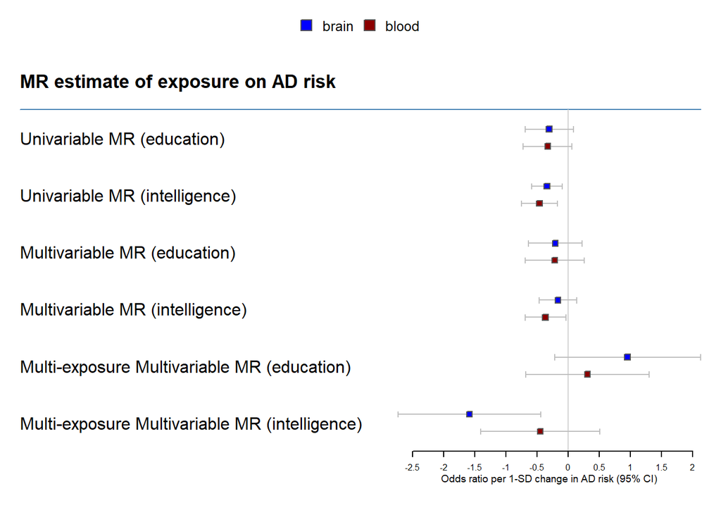

```r
# forest_plot_multi_exposure_MR
library(forestplot)
# forest_plot_single_exposure_MR
res_single_exposure_analysis = rbind(res_Okbay_brain_blood, res_Savage_brain_blood)
# forest_plot_univariable_MR
# The 3rd row is IVW estimate from univariable MR:
res_univariableMR_analysis = rbind(
  rbind(res_Okbay_brain[3, ], res_Okbay_blood[3, ]),
  rbind(res_Savage_brain[3, ], res_Savage_blood[3, ])
)
res_univariableMR_analysis = res_univariableMR_analysis[, colnames(res_main_analysis)]


res_all = rbind(res_univariableMR_analysis,
                rbind(res_single_exposure_analysis, res_main_analysis))
res_all$labeltext = c("Univariable MR (education)", "Univariable MR (education)",
                      "Univariable MR (intelligence)", "Univariable MR (intelligence)",
                      "Multivariable MR (education)", "Multivariable MR (education)",
                      "Multivariable MR (intelligence)", "Multivariable MR (intelligence)",
                      "Multi-exposure Multivariable MR (education)", "Multi-exposure Multivariable MR (education)",
                      "Multi-exposure Multivariable MR (intelligence)", "Multi-exposure Multivariable MR (intelligence)")

res_all$group = c("brain", "blood", "brain", "blood",
                  "brain", "blood", "brain", "blood",
                  "brain", "blood", "brain", "blood")

add_CI(res_all) |>
    group_by(group) |>
    rename(mean=b, lower=CI_lower, upper=CI_upper) |>
    forestplot(clip = c(-3, 2.5),
               ci.vertices = TRUE,
               ci.vertices.height = 0.05,
               boxsize = .1,
               xlab = "Odds ratio per 1-SD change in AD risk (95% CI)") |>
    fp_add_lines("steelblue") |>
    fp_add_header("MR estimate of exposure on AD risk") |>
    fp_set_style(box = c("blue", "darkred") |> lapply(function(x) gpar(fill = x, col = "#555555")),
                 default = gpar(vertices = TRUE))
```

**Multivariable Mendelian randomization results using tissue-specific-variants colocalizing with either blood tissue eQTL or brain tissue eQTL.** Forest plot illustrating the odds ratios for every 1-standard deviation (SD) change in risk and 95% confidence intervals (CI). The independent effects are estimated using a tissue-specific multivariable Mendelian randomization model by leveraging brain- and blood-tissue partitioned variants.